# Capstone: Memory Group Analysis

##### Renewal Likelihood

```r
#Renewal likelihood

#Issue there are outliers: is it sound to remove outliers at zero likelihood?
# Compute the analysis of variance
#res.aov = aov((Renewal.Liklihood_1)^2 ~ label, data = mat_retention_fin_1) square transformation

res.aov = aov((Renewal.Liklihood_1) ~ label, data = mat_retention_fin_1)

# Summary of the analysis
#summary(res.aov)

# Check Assumptions

#Equal Var: Satisfied

par(mfrow = c(1,2))

plot(res.aov,1)
bartlett.test(Renewal.Liklihood_1 ~ label, data = mat_retention_fin_1) #null: all populations variances are equal
```

```
##
##  Bartlett test of homogeneity of variances
##
## data:  Renewal.Liklihood_1 by label
## Bartlett's K-squared = 1.3125, df = 3, p-value = 0.7262
```

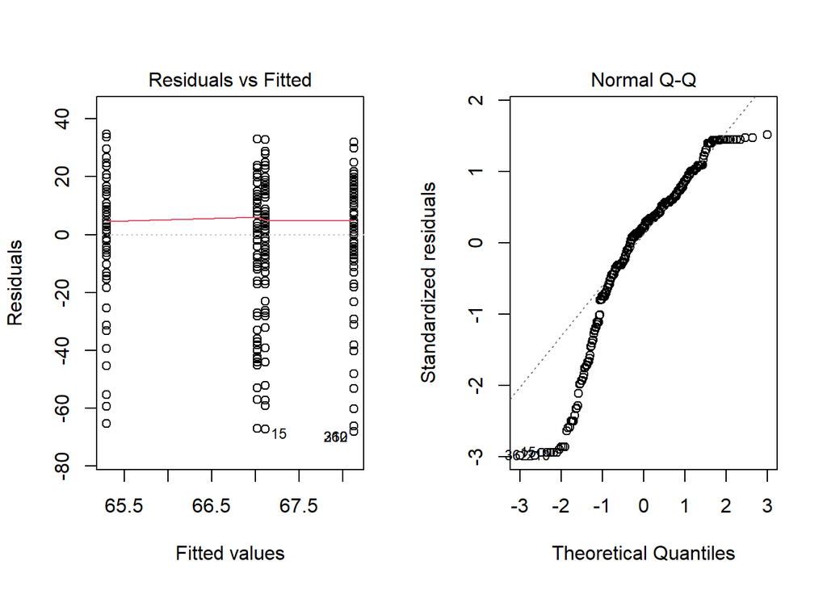

```r
#Normality: Failed --> tried square transformation and it helped but didn't completely fix
plot(res.aov,2)
```

```r
shapiro.test(res.aov$residuals) #null is that data is normally dist
```

```
##
##  Shapiro-Wilk normality test
##
## data:  res.aov$residuals
## W = 0.90316, p-value = 1.044e-14
```

There is a clear violation of normality so we must use specialty ANOVA tests that don’t require this assumption.

```r
#These versions don't need normality assumption
kruskal.test(Renewal.Liklihood_1 ~ label, data = mat_retention_fin_1) #same shape dist: verified --> check density plot
```

```
##
##  Kruskal-Wallis rank sum test
##
## data:  Renewal.Liklihood_1 by label
## Kruskal-Wallis chi-squared = 2.0124, df = 3, p-value = 0.5698
```

```r
pairwise.wilcox.test(mat_retention_fin_1$Renewal.Liklihood_1, mat_retention_fin_1$label,
                 p.adjust.method = "BH") #no p-value correction, alt use "BH"
```

```
##
##  Pairwise comparisons using Wilcoxon rank sum test with continuity correction
##
## data:  mat_retention_fin_1$Renewal.Liklihood_1 and mat_retention_fin_1$label
##
##                Control Categorization Ranking
## Categorization 0.86    -              -
## Ranking        0.78    0.77           -
## Reduced List   0.86    0.86           0.77
##
## P value adjustment method: BH
```

```r
#Finding: No difference in renewal likelihood across groups
```

These tests suggest that there is not a statistically significant difference in renewal likelihoods across conditions.

#### OLS

Alternatively to an ANOVA model, we can build a regression model to control for explanatory variables that may influence the effect of memory on renewal likelihood.

Linear regression model

$Renewal\ Likelihood^2 = \beta_0 +\ \beta_1\ memory\ score + \beta_2\ age\ bucket\ [35-50] + \beta_3\ age\ bucket\ [>50]$

```r
#y: renewal likelihood
#x: memory score, age buckets, gender, page time, buffer performance

reg_1 = lm((Renewal.Liklihood_1)^2 ~ memory_score + label + page_time + buffer_count, data = mat_retention_fin_1)

reg_1 = lm((Renewal.Liklihood_1)^2 ~ memory_score + age_bucket, data = filter(mat_retention_fin_1, label != "Reduced List"))

reg_1 = lm((Renewal.Liklihood_1)^2 ~ memory_score + age_bucket + Gender,
           data = filter(mat_retention_fin_1, Gender == "Female" | Gender == "Male")) #add gender var (no effect)

reg_1 = lm((Renewal.Liklihood_1)^2 ~ memory_score + age_bucket, data = mat_retention_fin_1) #selected model

summary(reg_1)
```

```
##
## Call:
## lm(formula = (Renewal.Liklihood_1)^2 ~ memory_score + age_bucket,
##     data = mat_retention_fin_1)
##
## Residuals:
##     Min      1Q  Median      3Q     Max
## -5187.0 -1591.9   130.3  1494.7  5429.9
##
## Coefficients:
##                         Estimate Std. Error t value Pr(>|t|)
## (Intercept)              4660.34     261.80  17.801   <2e-16 ***
## memory_score               90.27      53.97   1.673   0.0952 .
## age_bucket35-50           255.81     297.46   0.860   0.3904
## age_bucketOlder than 50  -296.69     377.31  -0.786   0.4322
## ---
## Signif. codes:  0 '***' 0.001 '**' 0.01 '*' 0.05 '.' 0.1 ' ' 1
##
## Residual standard error: 2551 on 370 degrees of freedom
## Multiple R-squared:  0.01295,    Adjusted R-squared:  0.004947
## F-statistic: 1.618 on 3 and 370 DF,  p-value: 0.1847
```

```r
summ(reg_1)
```

| Observations | 374 |
| --- | --- |
| Dependent variable | (Renewal.Liklihood_1)^2 |
| Type | OLS linear regression |

| F(3,370) | 1.62 |
| --- | --- |
| R² | 0.01 |
| Adj. R² | 0.00 |

|  | Est. | S.E. | t val. | p |
| --- | --- | --- | --- | --- |
| (Intercept) | 4660.34 | 261.80 | 17.80 | 0.00 |
| memory_score | 90.27 | 53.97 | 1.67 | 0.10 |
| age_bucket35-50 | 255.81 | 297.46 | 0.86 | 0.39 |
| age_bucketOlder than 50 | -296.69 | 377.31 | -0.79 | 0.43 |

Standard errors: OLS

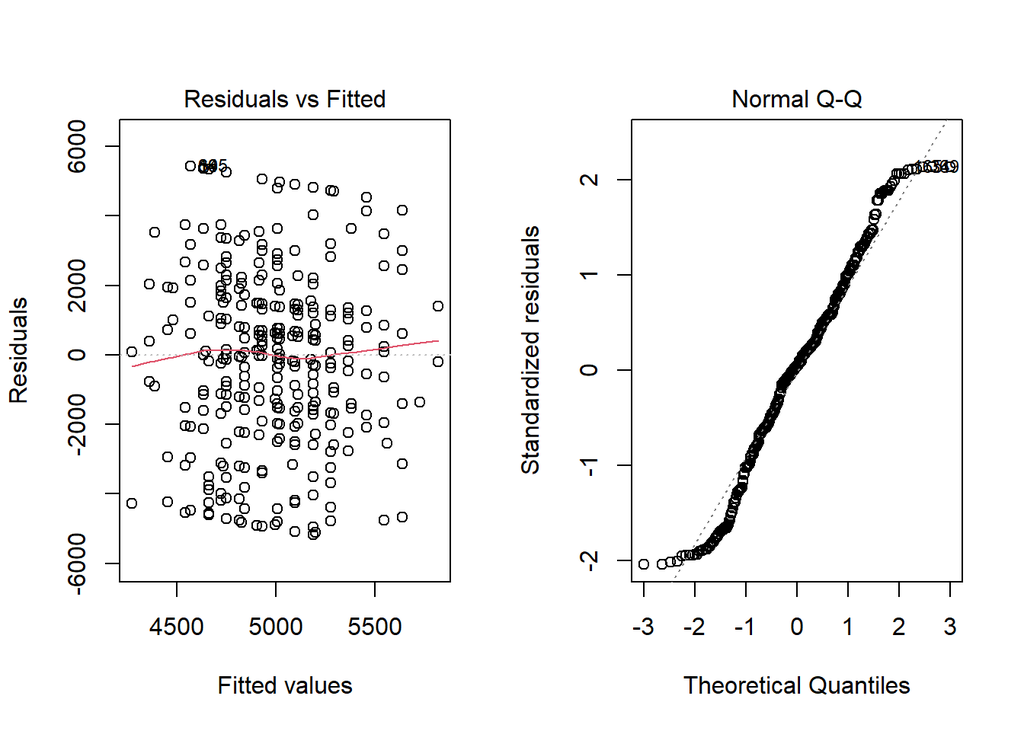

```r
par(mfrow = c(1,2))

plot(reg_1, which = 1:2) #constant var (mean zero), normal dist
```

```r
x = mat_retention_fin_1 %>%  dplyr::select(Renewal.Liklihood_1, memory_score, page_time, buffer_count)
cor(x, method = "pearson", use = "complete.obs") #multicollinearity check
```

```
##                     Renewal.Liklihood_1 memory_score  page_time buffer_count
## Renewal.Liklihood_1          1.00000000    0.1004013 0.04868748   0.02723551
## memory_score                 0.10040127    1.0000000 0.38729612   0.21675201
## page_time                    0.04868748    0.3872961 1.00000000   0.11432933
## buffer_count                 0.02723551    0.2167520 0.11432933   1.00000000
```

```r
#ppl more likely to renew when they remember
```

OLS Assumptions hold and there is a statistically significant relationship (at the 10% level) between benefit memory retention and renewal likelihood when controlling for age groups.

**Main Findings**

1. There is a positive and statistically significant (10%) relationship between renewal likelihood and memory. This suggests that individuals who remember the season ticket benefits more are more likely to renew their season tickets.
2. No significant treatment effects for memory nor renewal likelihood were found.
3. We would suggest that clearly communicating season ticket benefits to current holders plays a role in their likelihood to renew. Given that people don’t spend a considerable amount of time going through their emails, its crucial to clearly display the benefits to enhance individual’s memory retention.

#### Miscellaneous: Summary Stats & Payments

Summary Stats: Requested by the professor

```r
mat_retention_fin_1 %>%
  group_by(label) %>%
  summarise(mean_memory = mean(memory_score)) %>%
  arrange(-mean_memory)
```

```
## # A tibble: 4 x 2
##   label          mean_memory
##   <fct>                <dbl>
## 1 Categorization        3.48
## 2 Control               3.41
## 3 Ranking               3.16
## 4 Reduced List          2.44
```

```r
mat_retention_fin_1 %>%
  group_by(label) %>%
  summarise(mean_renewal = mean(Renewal.Liklihood_1)) %>%
  arrange(-mean_renewal)
```

```
## # A tibble: 4 x 2
##   label          mean_renewal
##   <fct>                 <dbl>
## 1 Categorization         68.1
## 2 Control                67.1
## 3 Reduced List           67.0
## 4 Ranking                65.3
```

Payments: Monetary payments to participants

```r
df_payments = cbind(MTurkID = df_1$MTurkID, Payment = mat_retention_fin_pre$user_payment) %>%
  data.frame() %>% arrange(MTurkID)

#write.csv(df_payments, "qualtrics_payments.csv")
```